# AirBnB Boston

Phil Chapman

08/04/2018

# 1 Introduction

In the analysis we use the structural topic modelling method from the R [stm package](https://www.structuraltopicmodel.com/) to analyse AirBnB listings data and identify topics that are related to the cost per night of the listing.

# 2 Analysis set up

## 2.1 Load libraries

```r
library(dplyr, quietly=TRUE)
library(tidyr, quietly=TRUE)
library(readr, quietly=TRUE)
library(purrr, quietly=TRUE)
library(stm, quietly=TRUE)
library(tidytext, quietly=TRUE)
library(ggplot2, quietly=TRUE)
library(quanteda, quietly=TRUE)
```

## 2.2 Load data

List the files in the data area. These were downloaded from Kaggle at https://www.kaggle.com/airbnb/boston.

```r
datapath <- '~/data/boston-airbnb-open-data/'
list.files(datapath)
```

```
## [1] "calendar.csv" "listings.csv" "reviews.csv"
```

Load the data into R using the `readr` package.

```r
listings <- readr::read_csv(file.path(datapath, 'listings.csv'))
dim(listings)
```

```
## [1] 3585   95
```

```r
colnames(listings)
```

```
##  [1] "id"                               "listing_url"
##  [3] "scrape_id"                        "last_scraped"
##  [5] "name"                             "summary"
##  [7] "space"                            "description"
##  [9] "experiences_offered"              "neighborhood_overview"
## [11] "notes"                            "transit"
## [13] "access"                           "interaction"
## [15] "house_rules"                      "thumbnail_url"
## [17] "medium_url"                       "picture_url"
## [19] "xl_picture_url"                   "host_id"
## [21] "host_url"                         "host_name"
## [23] "host_since"                       "host_location"
## [25] "host_about"                       "host_response_time"
## [27] "host_response_rate"               "host_acceptance_rate"
## [29] "host_is_superhost"                "host_thumbnail_url"
```

[output cut: 33 more lines]

# 3 Data preparation

## 3.1 Select data of interest

Only require some of the fields for later analysis. In particular we are interested in price and accomodation description. We also only want to analyse listings for an entire property.

```r
stm_df <- listings %>%
  dplyr::filter(grepl('Entire', room_type)) %>%
  dplyr::transmute(id, price=log(as.numeric(gsub('\\$', '', price))), comments=description) %>%
  dplyr::filter(!is.na(price))
stm_df
```

```
## # A tibble: 2,118 x 3
##          id price comments
##       <int> <dbl> <chr>
##  1 12147973  5.52 Cozy, sunny, family home.  Master bedroom high ceilings…
##  2  5706985  4.61 "It's a 5 minute walk to Rosi Square to catch the train…
##  3   849408  5.43 "This is a cozy and spacious two bedroom unit with ever…
##  4  2684840  4.53 Clean, sunny 2 bedroom in amazing Roslindale Village, 6…
##  5 13547301  5.01 My place is close to Public Transportation. The train s…
##  6  5434353  4.98 Enjoy the full space of our home as you explore some of…
##  7 13251243  4.79 "Lovely sun-filled private guest cottage set on single …
##  8  6400432  5.01 Three bedroom in Boston's Roslindale neighborhood - spa…
##  9  5498472  5.16 Our spacious, modern, immaculate town home is located i…
## 10  7093109  5.30 New totally renovated 2 bedroom apt located 30 minutes …
## # ... with 2,108 more rows
```

## 3.2 Tokenise and remove stopwords

Tidy the comments using the tidytext ‘bag of words’ approach bu tokenising and then removing stopwords with an anti-join.

```r
tidy_comments <- stm_df %>%
  unnest_tokens(word, comments) %>%
  anti_join(stop_words)
tidy_comments
```

```
## # A tibble: 154,330 x 3
##          id price word
##       <int> <dbl> <chr>
##  1 12147973  5.52 cozy
##  2 12147973  5.52 sunny
##  3 12147973  5.52 family
##  4 12147973  5.52 home
##  5 12147973  5.52 master
##  6 12147973  5.52 bedroom
##  7 12147973  5.52 ceilings
##  8 12147973  5.52 deck
##  9 12147973  5.52 garden
## 10 12147973  5.52 hens
## # ... with 154,320 more rows
```

## 3.3 Examine the number of words extracted

We can count the number of words present following tokensiation:

```r
tidy_comments %>%
  count(word, sort=TRUE)
```

```
## # A tibble: 7,650 x 2
##    word          n
##    <chr>     <int>
##  1 boston     2825
##  2 apartment  2345
##  3 kitchen    1659
##  4 walk       1590
##  5 bedroom    1582
##  6 bed        1363
##  7 located    1248
##  8 living     1186
##  9 2          1142
## 10 street     1131
## # ... with 7,640 more rows
```

Then extract the most common 1000 words to be used in the analysis

```r
common_words <- tidy_comments %>%
  count(word, sort=TRUE) %>%
  top_n(1000,n) %>% dplyr::select(-n)
common_words
```

```
## # A tibble: 1,032 x 1
##    word
##    <chr>
##  1 boston
##  2 apartment
##  3 kitchen
##  4 walk
##  5 bedroom
##  6 bed
##  7 located
##  8 living
##  9 2
## 10 street
## # ... with 1,022 more rows
```

## 3.4 Create a document term frequency matrix

The tidy comments data frame can be converted into a document term frequency matrix using the `tidytext::cast_dfm` function. The object type is a `dfm` object from the `quanteda` package.

```r
comments_dfm <- tidy_comments %>%
  inner_join(common_words) %>%
  count(id, word) %>%
  arrange(id) %>%
  tidytext::cast_dfm(id, word, n)
comments_dfm
```

```
## Document-feature matrix of: 2,117 documents, 1,032 features (95.2% sparse).
```

## 3.5 Make a metadata data frame

In order to include covariates in the Structural Topic Model, we also need to create a metadata data frame. In this case the covariate of interest is the price of the listing. Importantly the rownames of the metadata dataframe must be the document id (ie listing id in this case).

```r
comments_dfm_meta <- stm_df %>%
  dplyr::group_by(id, price) %>%
  dplyr::summarise(comments=dplyr::first(comments)) %>%
  ungroup() %>%
  dplyr::filter(id %in% docnames(comments_dfm)) %>%
  dplyr::arrange(id) %>%
  as.data.frame()
rownames(comments_dfm_meta) <- comments_dfm_meta$listing_id
```

## 3.6 Create an stm corpus object

Now convert the dataframes in an stm corpus object

```r
comments_stmc <- asSTMCorpus(comments_dfm, data=comments_dfm_meta)
```

# 4 Topic modelling

## 4.1 Identify optimal value of K

### 4.1.1 Set up search grid

Specify the range of topic numbers that we want to search. Since we can parallise across up to 16 cores we will look at 30 different values of K - leaving one core free.

```r
n_topics <- seq(4,33,1)
length(n_topics)
```

```
## [1] 30
```

### 4.1.2 Run the grid search

Now run the grid search over the 30 values of K specified.

```r
topic_store <- searchK(comments_stmc$documents,
  comments_stmc$vocab,
  K = n_topics,
  data = comments_stmc$data,
  prevalence = ~ price,
  max.em.its = 20,
  cores = 15)
```

### 4.1.3 Evaluate the models generated

The stm package includes functionality to generate some useful diagnostic plots:

```r
plot(topic_store)
```

[output not shown]

Not very clear in this case, probably don’t have sufficient observations, but 8 looks reasonable.

```r
best_k <- 8
```

## 4.2 Fit the topic model

Now fit the topic model with the chosen number of topics.

```r
topic_model <- stm(comments_stmc$documents,
  comments_stmc$vocab,
  K = best_k,
  data = comments_stmc$data,
  prevalence = ~ price,
  max.em.its = 20,
  verbose=FALSE)
```

Generate a summary of the topic model. For each topic, the topi words according to four different metrics are generated. Top probability is just the most common words, the other metrics use different forms of weighting to pick up words that are more exlusive to the topic. See the stm vignette and package documentation for more information.

```r
summary(topic_model)
```

```
## A topic model with 8 topics, 2117 documents and a 1032 word dictionary.
```

```
## Topic 1 Top Words:
##       Highest Prob: tv, features, apartment, unit, internet, dryer, appliances
##       FREX: steel, granite, utilities, stainless, counter, marble, oven
##       Lift: lacquer, teaching, wine, vary, vacuum, controls, housewares
##       Score: wine, stainless, suites, steel, utilities, lacquer, teaching
## Topic 2 Top Words:
##       Highest Prob: bedroom, bed, kitchen, living, queen, 2, floor
##       FREX: beds, level, size, queen, twin, shower, sized
##       Lift: details, sqft, blow, den, spread, larger, total
##       Score: details, size, bed, queen, bedroom, living, level
## Topic 3 Top Words:
##       Highest Prob: towels, 24, spacious, local, book, apartment, you’ll
##       FREX: flatbook, book, contact, fluffy, ready, team, design
##       Lift: catering, contact, we’re, flatbook, fluffy, layouts, team
##       Score: contact, flatbook, fluffy, team, we’re, book, you’ll
## Topic 4 Top Words:
##       Highest Prob: line, restaurants, boston, green, apartment, minutes, walk
##       FREX: jamaica, plain, bus, green, orange, pond, arboretum
##       Lift: brookline, arboretum, arnold, pond, jamaica, plain, circle
##       Score: brookline, jamaica, bus, plain, line, pond, orange
## Topic 5 Top Words:
##       Highest Prob: boston, amenities, apartment, apartments, luxury, fitness, district
##       FREX: theater, fitness, site, pool, basketball, community, entertainment
##       Lift: preference, bay’s, fenway’s, games, standout, you’re, epitomize
##       Score: games, fitness, apartments, bay’s, fenway’s, you’re, building’s
## Topic 6 Top Words:
##       Highest Prob: boston, north, street, apartment, restaurants, walk, steps
##       FREX: north, couples, adventurers, newbury, travelers, steps, trail
##       Lift: adventurers, church, furry, haymarket, navy, bunker, italy
##       Score: adventurers, north, couples, travelers, freedom, you’ll, trail
## Topic 7 Top Words:
##       Highest Prob: walk, station, minute, boston, parking, 5, 10
##       FREX: airport, station, 10, minute, min, 5, logan
##       Lift: hostel, suggested, permit, maverick, primarily, amenity, logan
##       Score: hostel, station, minute, airport, 10, min, suggested
## Topic 8 Top Words:
##       Highest Prob: apartment, boston, building, hill, located, studio, beacon
##       FREX: solo, beacon, hill, common, check, studio, keys
##       Lift: solo, operated, roofdeck, professionally, cell, blender, keys
##       Score: solo, beacon, hill, studio, common, check, couch
```

## 4.3 Estimate the effect of price

Now estimate the effect of the price covariate on the prevalence of each topic:

```r
est_effect <- estimateEffect(1:best_k ~ price, topic_model, meta=comments_dfm_meta)
```

# 5 Explore topic model

## 5.1 Basic plots

### 5.1.1 Convergence

How well did the topic model converge?

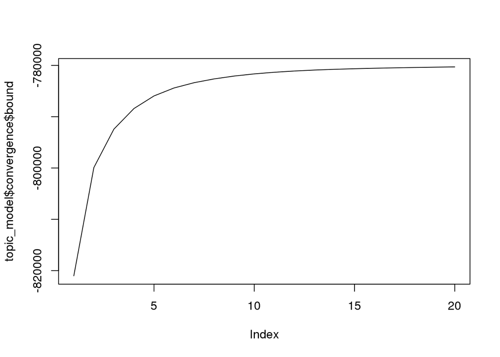

```r
plot(topic_model$convergence$bound, type='l')
```

### 5.1.2 Overview of topics

Let’s see a summary of the topic model.

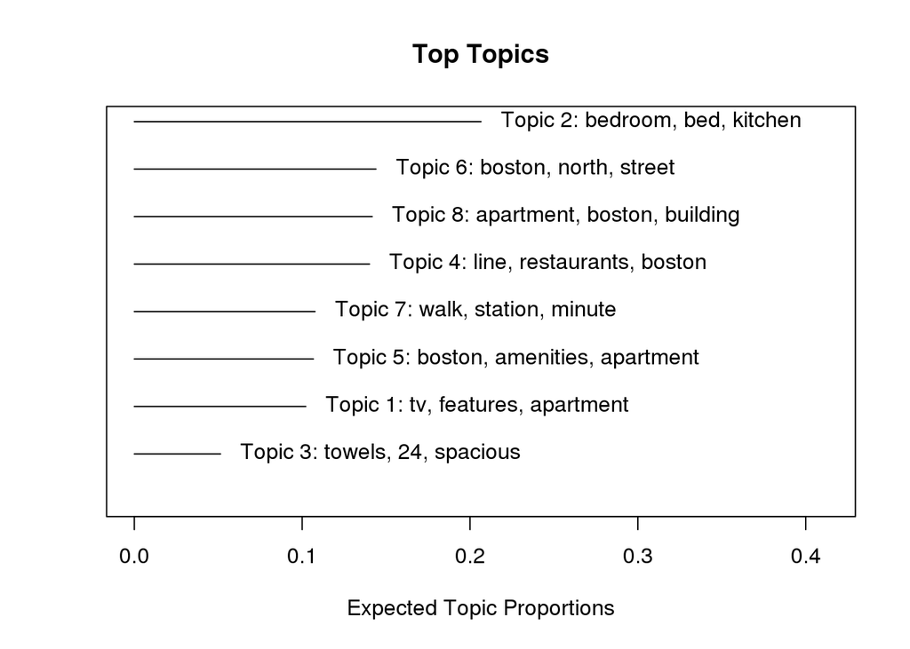

```r
plot(topic_model, type='summary')
```

## 5.2 Explore covariate effects

### 5.2.1 Visualise effects

First just plot the effect of price on topic prevalence for topics 1-4:

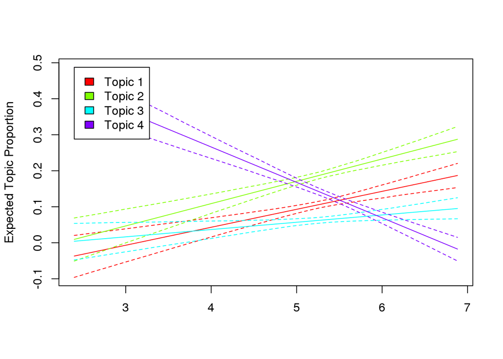

```r
plot(est_effect, covariate='price', method='continuous', topics=1:4)
```

And now topics 5-8

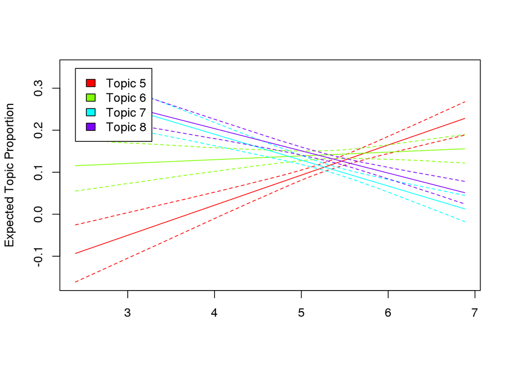

```r
plot(est_effect, covariate='price', method='continuous', topics=5:8)
```

### 5.2.2 Focus on topics 1 and 7

What are topics 1 and 7? These seem to have a positive and negative relationship with price respectively (up vs down slope).

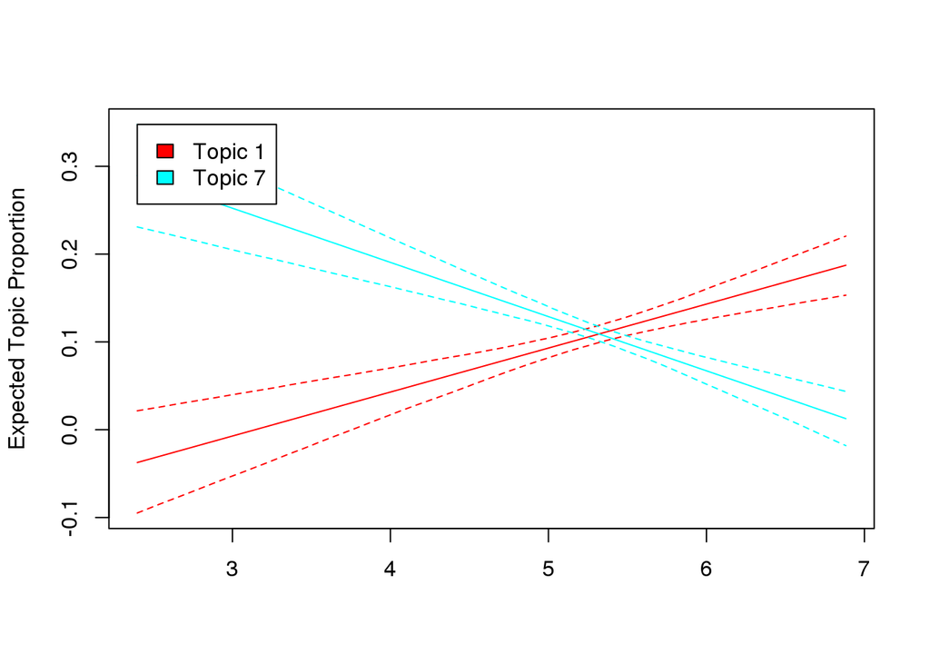

```r
plot(est_effect, covariate='price', method='continuous', topics=c(1,7))
```

Terms like boston and appartment tend to appear in many topics, so in this case looking at FREX, score and lift is useful as we see words exclusive to these topics.

```r
labelTopics(topic_model, c(1,7), n=10)
```

```
## Topic 1 Top Words:
##       Highest Prob: tv, features, apartment, unit, internet, dryer, appliances, stainless, property, washer
##       FREX: steel, granite, utilities, stainless, counter, marble, oven, rental, tops, appliances
##       Lift: lacquer, teaching, wine, vary, vacuum, controls, housewares, ironing, 42, length
##       Score: wine, stainless, suites, steel, utilities, lacquer, teaching, 42, granite, tops
## Topic 7 Top Words:
##       Highest Prob: walk, station, minute, boston, parking, 5, 10, south, downtown, min
##       FREX: airport, station, 10, minute, min, 5, logan, seaport, train, mins
##       Lift: hostel, suggested, permit, maverick, primarily, amenity, logan, airport, garages, track
##       Score: hostel, station, minute, airport, 10, min, suggested, train, 5, stylishly
```

Generate a wordcloud of most common terms for each:

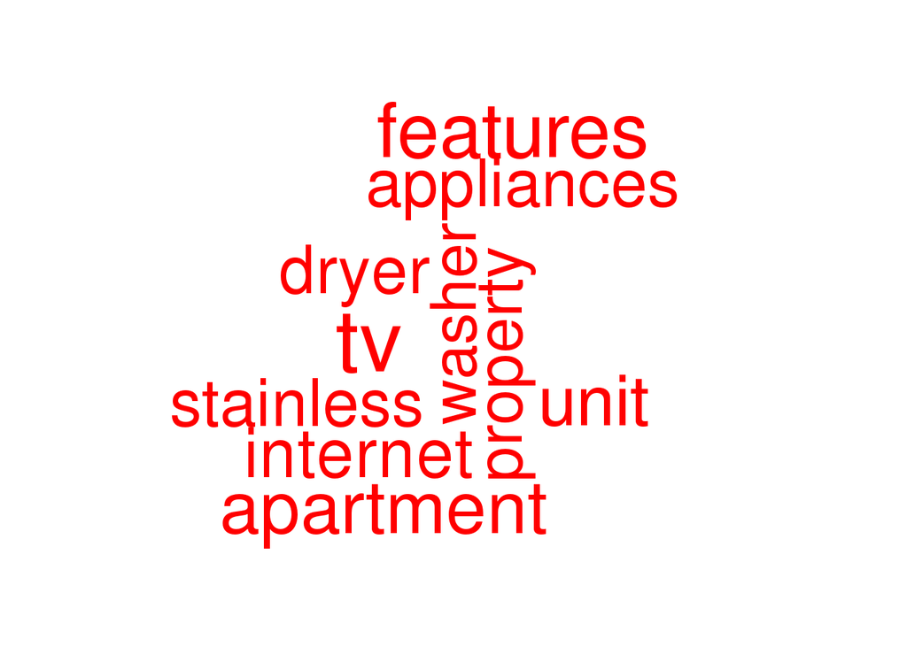

```r
cloud(topic_model, topic=1, max.words = 10, color='red')
```

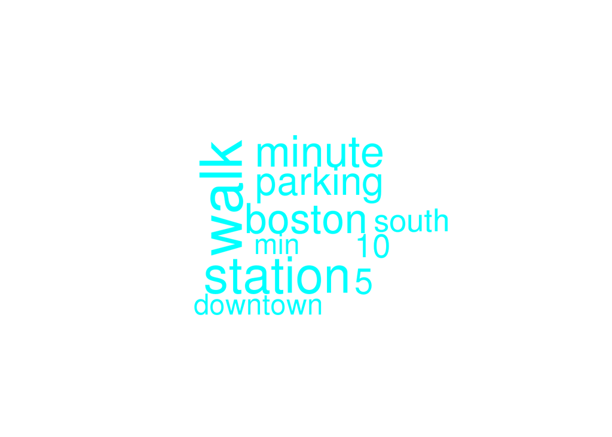

```r
cloud(topic_model, topic=7, max.words = 10, color='cyan')
```

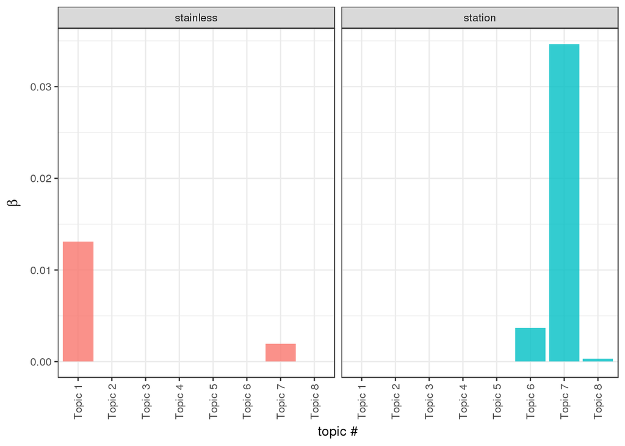

```r
tidy(topic_model) %>%
  dplyr::filter(term %in% c('stainless', 'station')) %>%
  ggplot(aes(x=paste('Topic', topic), y=beta, fill=term)) +
    geom_col(alpha=0.8, show.legend=FALSE) +
    facet_wrap(~term)  +
    labs(x='topic #', y=expression(beta)) +
    theme_bw() + theme(axis.text.x=element_text(angle=90, vjust=0.5))
```

### 5.2.3 Combined plot of all topics

In the plot below, the top terms for each topic are plotted, and colour represents the steepness of the slope of the regression line.

First extract topic betas with tidytext tidier.

```r
topic_top_terms <- tidy(topic_model) %>%
  group_by(topic) %>%
  top_n(10,beta) %>%
  ungroup()
topic_top_terms
```

```
## # A tibble: 80 x 3
##    topic term        beta
##    <int> <chr>      <dbl>
##  1     2 1         0.0169
##  2     7 10        0.0206
##  3     2 2         0.0237
##  4     3 24        0.0179
##  5     7 5         0.0224
##  6     5 amenities 0.0245
##  7     1 apartment 0.0149
##  8     3 apartment 0.0154
##  9     4 apartment 0.0185
## 10     5 apartment 0.0170
## # ... with 70 more rows
```

Then extract slopes from the effectEstimate object:

```r
slope_ests <- tidyr::crossing(topic=1:best_k, rep=1:20) %>%
  mutate(slope_est = map2_dbl(topic, rep, ~est_effect$parameters[[.x]][[.y]]$est['price'])) %>%
  group_by(topic) %>%
  summarise(slope_est=mean(slope_est))
slope_ests
```

```
## # A tibble: 8 x 2
##   topic slope_est
##   <int>     <dbl>
## 1     1   0.0498
## 2     2   0.0617
## 3     3   0.0197
## 4     4  -0.0989
## 5     5   0.0719
## 6     6   0.00868
## 7     7  -0.0606
## 8     8  -0.0524
```

To make the plot, join the top terms and the slope estimates and then facet by topoic,. Interpret the plot as below:

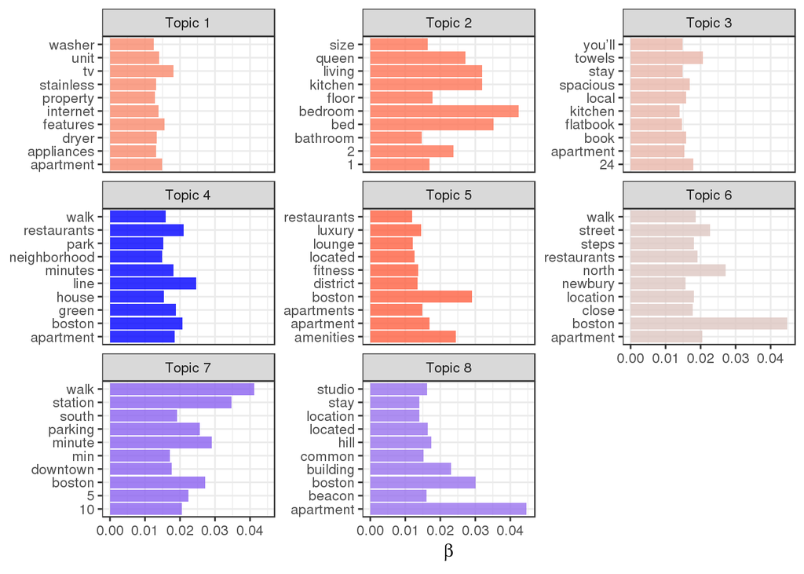

```r
topic_top_terms %>%
  inner_join(slope_ests) %>%
  mutate(topic = paste0('Topic ', topic)) %>%
  ggplot(aes(term, beta, fill=slope_est)) +
    geom_col(alpha=0.8, show.legend=FALSE) +
    scale_fill_gradient2(high='red', mid='lightgray', low='blue') +
    facet_wrap(~ topic, scales='free_y') +
    coord_flip() +
    labs(x=NULL, y=expression(beta)) + theme_bw()
```

# 6 Conclusions

Using structual topic modelling on AirBnb data we are able to identify topics that are related to high and low price listings. For example, a topic associated with the term ‘luxury’ was associated with high price, and a topic associated with ‘studio’ was associated with low price.

# 7 Session Info

```r
Sys.time()
```

```
## [1] "2018-04-10 08:43:57 UTC"
```

```r
cat(paste(readLines('/etc/docker/docker_info.txt'), '\n'))
```

```
##
##  ################################
##  # DOCKER BUILD INFORMATION
##  ################################
##
##  This is docker image: chs-stage-11b-nlp-spacy-temp
##  See /etc/docker/docker_build_history.txt for provenance of this environment.
##  See /etc/docker for more information
##
##  ################################
```

```r
cat(paste(readLines('/etc/docker/docker_build_history.txt'), '\n'))
```

[output not shown]